# Lab 06 - Text Mining

# Learning goals

- Use tokenization and n-grams to extract features from text
- Use pandas and plotnine to analyze and visualize text data
- Apply sentence tokenization to analyze text structure
- Apply topic modeling using scikit-learn and see if topics align with medical specialties

# Lab description

For this lab we will be working with the medical record transcriptions from https://www.mtsamples.com/ available at https://github.com/salgadev/medical-nlp.

# Deliverables

1. Questions 1-7 answered, rendered to html and uploaded to Quercus.
2. Add link to your github repo in your html.

### Setup packages

You should have the following packages installed: `pandas`, `numpy`, `plotnine`, `nltk`, `wordcloud`, and `scikit-learn`.

```python
import pandas as pd
import numpy as np
import matplotlib.pyplot as plt
from collections import Counter
import re

# Plotting with ggplot2 syntax
from plotnine import *

# Text processing
import nltk
from nltk.tokenize import word_tokenize, sent_tokenize
from nltk.corpus import stopwords
from nltk.util import ngrams
nltk.download('punkt')
nltk.download('stopwords')
nltk.download('punkt_tab')

# Word cloud
from wordcloud import WordCloud

# Topic modeling
from sklearn.feature_extraction.text import CountVectorizer, TfidfVectorizer
from sklearn.decomposition import LatentDirichletAllocation
```

## Read in the Medical Transcriptions

Loading in reference transcription samples from https://www.mtsamples.com/

```python
mt_samples = pd.read_csv("https://raw.githubusercontent.com/salgadev/medical-nlp/master/data/mtsamples.csv")
mt_samples = mt_samples[['description', 'medical_specialty', 'transcription']]

mt_samples.head()
```

|  | description | medical_specialty | transcription |
| --- | --- | --- | --- |
| 0 | A 23-year-old white female presents with comp... | Allergy / Immunology | SUBJECTIVE:, This 23-year-old white female pr... |
| 1 | Consult for laparoscopic gastric bypass. | Bariatrics | PAST MEDICAL HISTORY:, He has difficulty climb... |
| 2 | Consult for laparoscopic gastric bypass. | Bariatrics | HISTORY OF PRESENT ILLNESS: , I have seen ABC ... |
| 3 | 2-D M-Mode. Doppler. | Cardiovascular / Pulmonary | 2-D M-MODE: , ,1. Left atrial enlargement wit... |
| 4 | 2-D Echocardiogram | Cardiovascular / Pulmonary | 1. The left ventricular cavity size and wall ... |

## Question 1: What specialties do we have?

We can use `value_counts()` from pandas to figure out how many different medical specialties are in the data. Are these categories related? overlapping? evenly distributed? Make a bar plot.

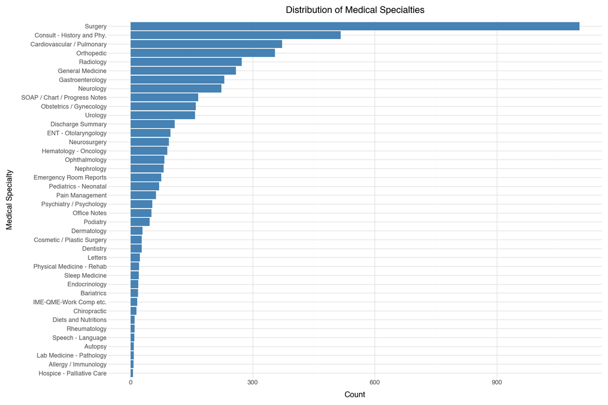

```python
specialty_counts = mt_samples['medical_specialty'].value_counts().reset_index()  # Hint: count categories
specialty_counts.columns = ['medical_specialty', 'count']

(ggplot(specialty_counts, aes(x='reorder(medical_specialty, count)', y='count'))  # Hint: use the counts dataframe
 + geom_bar(stat='identity', fill='steelblue')
 + coord_flip()
 + labs(x='Medical Specialty', y='Count', title='Distribution of Medical Specialties')
 + theme_minimal()
 + theme(figure_size=(12, 8))
)
```

Summarize the top medical specialties:

The most common specialty is Surgery, followed by Consult - History and Phy., Cardiovascular / Pulmonary, Orthopedic, and Radiology. In general, the distribution is imbalanced, i.e., a few specialties have a lot of samples, and the rest have very small counts.

## Question 2: Tokenize

- Tokenize the words in the `transcription` column
- Count the number of times each token appears
- Visualize the top 20 most frequent words with a bar plot

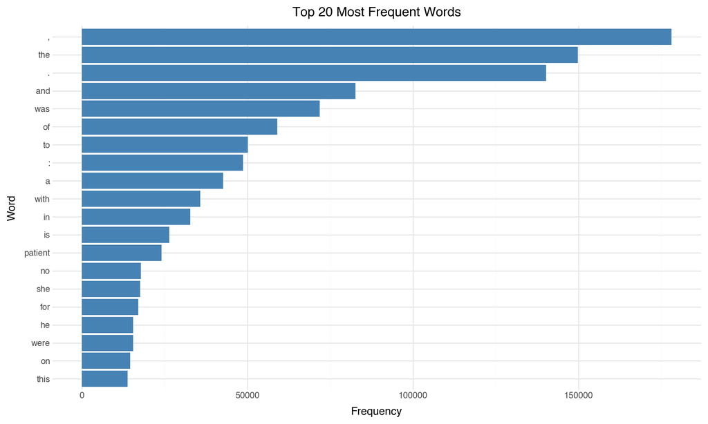

```python
# Tokenize all transcriptions
def tokenize_text(text):
    if pd.isna(text):
        return []
    return word_tokenize(text.lower())  # Hint: NLTK word tokenizer

all_tokens = []
for text in mt_samples['transcription']:
    all_tokens.extend(tokenize_text(text))

# Count tokens
token_counts = Counter(all_tokens)  # Hint: count token frequencies
top_20 = token_counts.most_common(20)  # Hint: top N entries

# Create dataframe for plotting
top_20_df = pd.DataFrame(top_20, columns=['word', 'count'])  # Hint: the top-20 list

# Bar plot with plotnine
(ggplot(top_20_df, aes(x='reorder(word, count)', y='count'))  # Hint: the top-20 dataframe
 + geom_bar(stat='identity', fill='steelblue')
 + coord_flip()
 + labs(x='Word', y='Frequency', title='Top 20 Most Frequent Words')
 + theme_minimal()
 + theme(figure_size=(10, 6))
)
```

Summarize the top 20 tokens and explain what insights (if any) do we get?

It is very obvious that punctuations and stopwords are the most frequent words in the data. Without removing them, we cannot find out medical themes.

## Question 3: Stopwords

- Redo Question 2 but remove stopwords
- Use NLTK’s stopwords list
- Use regex to remove numbers

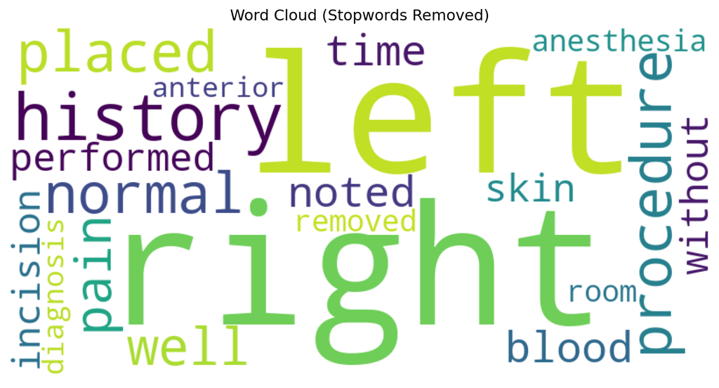

```python
# Get English stopwords
stop_words = set(stopwords.words('english'))  # Hint: get stopword list

# Add custom stopwords
custom_stopwords = {'patient', 'also', 'using', 'used'}
stop_words = stop_words.union(custom_stopwords)

# Filter tokens
filtered_tokens = [
    token for token in all_tokens
    if token not in stop_words
    and not token.isdigit()  # Hint: filter out pure numbers
    and len(token) > 2  # Remove very short tokens
    and token.isalpha()  # Keep only alphabetic tokens
]

# Count filtered tokens
filtered_counts = Counter(filtered_tokens)
top_20_filtered = filtered_counts.most_common(20)

# Create dataframe for plotting
top_20_filtered_df = pd.DataFrame(top_20_filtered, columns=['word', 'count'])

# Bar plot with plotnine
(ggplot(top_20_filtered_df, aes(x='reorder(word, count)', y='count'))
 + geom_bar(stat='identity', fill='steelblue')
 + coord_flip()
 + labs(x='Word', y='Frequency', title='Top 20 Most Frequent Words (Stopwords Removed)')
 + theme_minimal()
 + theme(figure_size=(10, 6))
)

# Word cloud
wordcloud = WordCloud(width=800, height=400, background_color='white').generate_from_frequencies(dict(top_20_filtered))
plt.figure(figsize=(10, 5))
plt.imshow(wordcloud, interpolation='bilinear')
plt.axis('off')
plt.title('Word Cloud (Stopwords Removed)')
plt.show()
```

Summarize: What do we see when you remove stopwords? Does it give us a better idea of what the text is about?

## Question 3b: Custom stopwords

- Import clinical-specific stopwords from the github repository and apply additional filtering. These stopwords are tailored for medical/clinical text and include terms like “patient”, “medical”, “clinical”, etc.
- Try further customizing your stopwords list to include 3-4 additional words of your own that do not appear informative

```python
# Import clinical stopwords from the medical-nlp repository
import urllib.request

clinical_stopwords_url = "https://raw.githubusercontent.com/salgadev/medical-nlp/master/data/clinical-stopwords.txt"
response = urllib.request.urlopen(clinical_stopwords_url)
clinical_stopwords_raw = response.read().decode('utf-8')


clinical_stopwords = set()
for line in clinical_stopwords_raw.split('\n'):
    line = line.strip().lower()
    if line and not line.startswith('#'):
        clinical_stopwords.add(line)

print(f"Number of clinical stopwords: {len(clinical_stopwords)}")
print(f"Sample clinical stopwords: {list(clinical_stopwords)[:20]}")
```

```
Number of clinical stopwords: 806
Sample clinical stopwords: ['seeminger', 'neath', 'umpteen', 'soest', 'thouses', 'latterly', 'accordingly', 'he', 'follow', 'non', 'lot', 'canted', 'whereon', 'doth', 'ons', 'onto', 'must', 'besides', 'of', 'anyone']
```

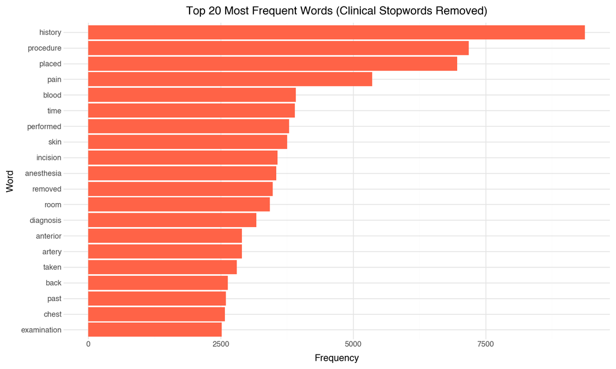

```python
# Combine NLTK stopwords with clinical stopwords
all_stopwords = stop_words.union(clinical_stopwords)

# Add custom stopwords
additional_stopwords = {'left', 'right', 'normal', 'noted'}  # Hint: add 3-4 clinical filler words
all_stopwords = all_stopwords.union(additional_stopwords)  # Hint: set merge

# Filter tokens using combined stopwords
clinical_filtered_tokens = [
    token for token in all_tokens
    if token not in all_stopwords
    and not re.match(r'^\d+$', token)
    and len(token) > 2
    and token.isalpha()
]

# Count filtered tokens
clinical_filtered_counts = Counter(clinical_filtered_tokens)  # Hint: tokens after clinical filtering
top_20_clinical = clinical_filtered_counts.most_common(20)  # Hint: top N

# Create dataframe for plotting
top_20_clinical_df = pd.DataFrame(top_20_clinical, columns=['word', 'count'])  # Hint: top list for plotting

# Bar plot with plotnine
(ggplot(top_20_clinical_df, aes(x='reorder(word, count)', y='count'))  # Hint: clinical top-20 dataframe
 + geom_bar(stat='identity', fill='tomato')
 + coord_flip()
 + labs(x='Word', y='Frequency', title='Top 20 Most Frequent Words (Clinical Stopwords Removed)')
 + theme_minimal()
 + theme(figure_size=(10, 6))
)
```

Summarize: How many clinical stopwords are there? What additional words did you remove? Do the results differ significantly when using clinical stopwords vs. general stopwords?

There are 806 clinical stopwords. I removed “left”, “right”, “normal”, and “noted” in addtion. When using clinical stopwords, we can spot more medical themes then the scenario using general stopwords. The updated top stop words are more towards the medical domain.

## Question 4: Bigrams

Tokenize the stopword-filtered transcriptions into bigrams and visualize the top 20 most frequent bigrams.

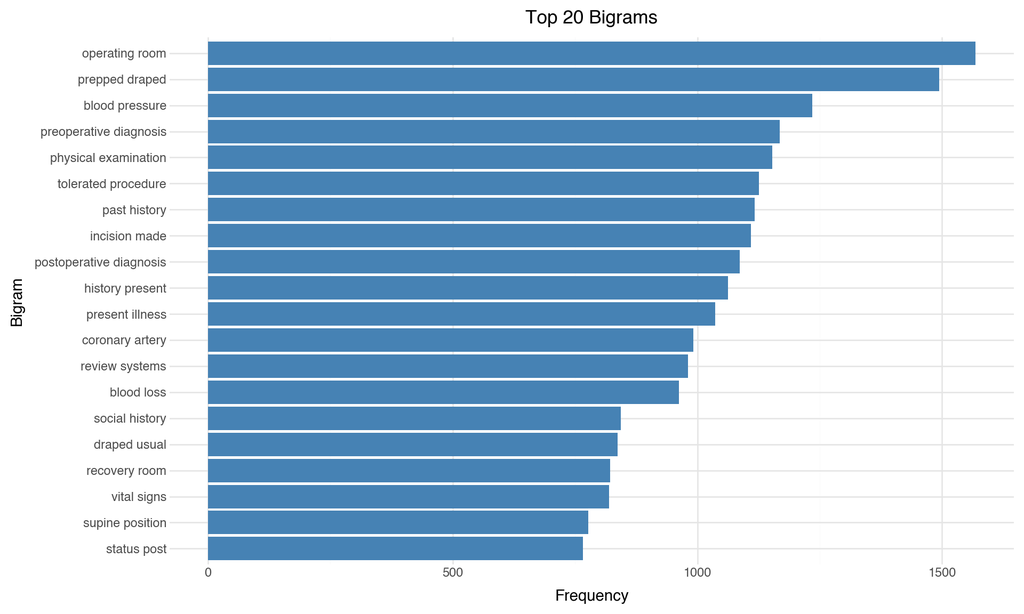

```python
def get_bigrams_from_text(text):
    if pd.isna(text):  # Hint: current text input
        return []
    tokens = word_tokenize(text.lower())  # Hint: lowercase text
    # Filter tokens using clinical stopwords
    tokens = [t for t in tokens if t not in all_stopwords and t.isalpha() and len(t) > 2]  # Hint: minimum length
    return list(ngrams(tokens, 2))  # Hint: bigram helper


all_bigrams = []
for text in mt_samples['transcription']:
    all_bigrams.extend(get_bigrams_from_text(text))

bigram_counts = Counter(all_bigrams)  # Hint: count bigrams
top_20_bigrams = bigram_counts.most_common(20)

# Create dataframe for bigrams
bigram_df = pd.DataFrame([
    {'bigram': ' '.join(bg), 'count': count}
    for bg, count in top_20_bigrams
])


(ggplot(bigram_df, aes(x='reorder(bigram, count)', y='count'))  # Hint: bigram dataframe
 + geom_bar(stat='identity', fill='steelblue')
 + coord_flip()
 + labs(x='Bigram', y='Frequency', title='Top 20 Bigrams')
 + theme_minimal()
 + theme(figure_size=(10, 6))
)
```

Summarize: do the bigrams make sense

The biagrams make sense. They are mostly common clinical phrases, such as “operation room”, “blood pressure” etc. Therefore, the biagrams capture meaningful medical themes then single words.

## Question 5: Examining bigram words

Using the results from the bigram, pick a word and count the words that appear before and after it, and create a plot of the top 20.

```python
# Pick a word to examine (e.g., 'blood', 'operating', 'diagnosis')
target_word = 'blood'  # Hint: choose a common token

# Find bigrams containing the target word
before_words = []
after_words = []

for bigram, count in bigram_counts.items():
    if bigram[1] == target_word:  # Hint: compare to chosen token
        before_words.extend([bigram[0]] * count)
    if bigram[0] == target_word:  # Hint: compare to chosen token
        after_words.extend([bigram[1]] * count)

# Count words
before_counts = Counter(before_words).most_common(20)  # Hint: top N
after_counts = Counter(after_words).most_common(20)  # Hint: top N

# Create dataframes
before_df = pd.DataFrame(before_counts, columns=['word', 'count'])  # Hint: counts before target
before_df['position'] = 'before'

after_df = pd.DataFrame(after_counts, columns=['word', 'count'])  # Hint: counts after target
after_df['position'] = 'after'
```

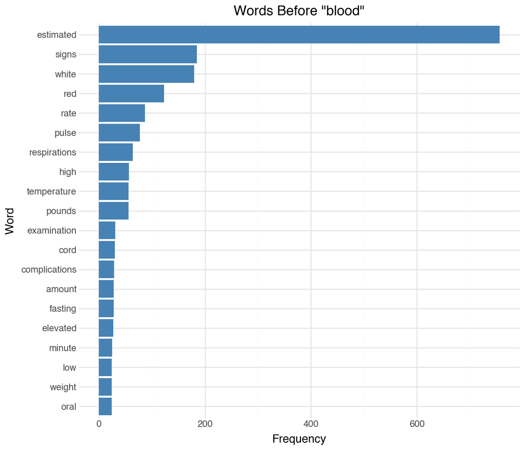

```python
# Plot words before
(ggplot(before_df, aes(x='reorder(word, count)', y='count'))  # Hint: dataframe of words before
 + geom_bar(stat='identity', fill='steelblue')
 + coord_flip()
 + labs(x='Word', y='Frequency', title=f'Words Before "{target_word}"')  # Hint: chosen word
 + theme_minimal()
 + theme(figure_size=(7, 6))
)
```

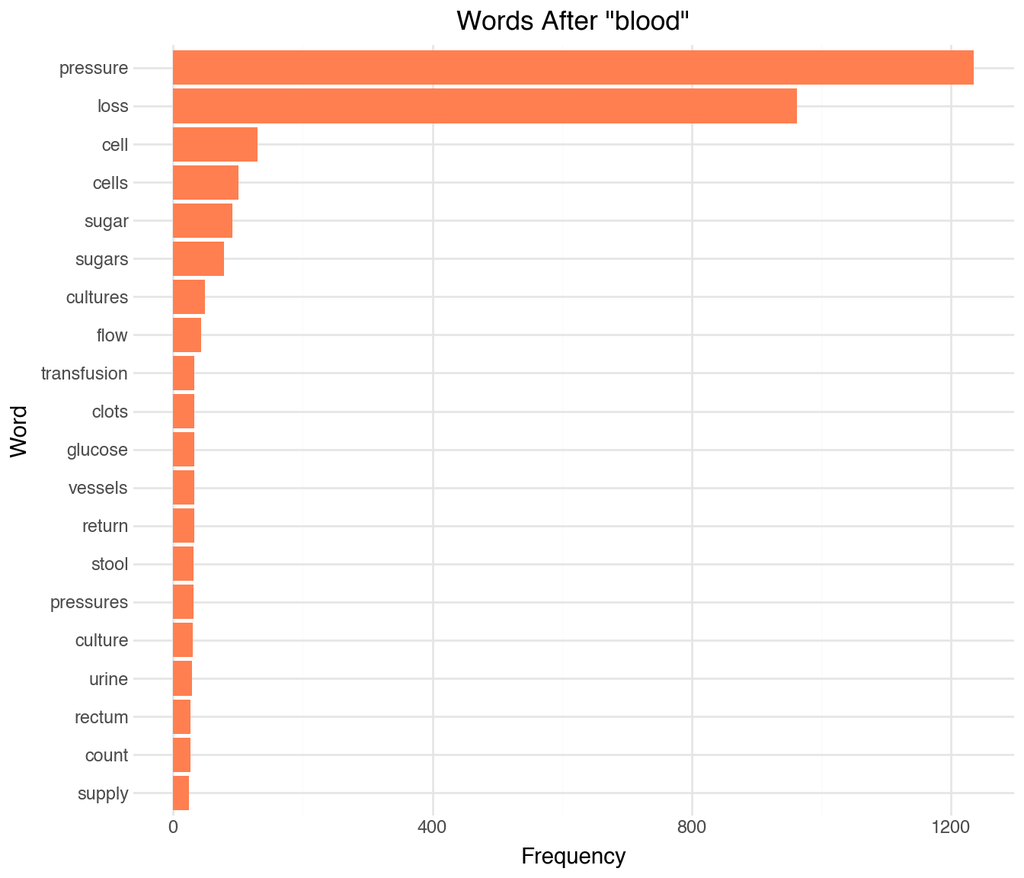

```python
# Plot words after
(ggplot(after_df, aes(x='reorder(word, count)', y='count'))  # Hint: dataframe of words after
 + geom_bar(stat='identity', fill='coral')
 + coord_flip()
 + labs(x='Word', y='Frequency', title=f'Words After "{target_word}"')  # Hint: chosen word
 + theme_minimal()
 + theme(figure_size=(7, 6))
)
```

Briefly summarize the bigram before and after words.

For the words before “blood”, they are mostly measurement terms, such as “estimated”, “signs”. For the words after “blood”, they are mostly standard medical terms such as “pressure”, “loss”, etc, and some lab terms such as “cell(s)”, “sugar(s)”, etc.

## Question 6: Sentence Tokenization

Tokenize the transcriptions into sentences and analyze sentence-level statistics.

- Count the number of sentences per transcription
- Calculate the average sentence length (in words) per transcription
- Plot the distribution of average sentence length
- Make a boxplot of the average sentence length by specialty

```python
# Tokenize transcriptions into sentences
def get_sentence_stats(text):
    if pd.isna(text):
        return {'num_sentences': 0, 'avg_sentence_length': 0}

    sentences = sent_tokenize(text)  # Hint: sentence tokenizer
    num_sentences = len(sentences)

    if num_sentences == 0:
        return {'num_sentences': 0, 'avg_sentence_length': 0}

    # Calculate average sentence length in words
    sentence_lengths = [len(word_tokenize(sent)) for sent in sentences]
    avg_length = np.mean(sentence_lengths)

    return {'num_sentences': num_sentences, 'avg_sentence_length': avg_length}  # Hint: use computed values

# Apply to all transcriptions
sentence_stats = mt_samples['transcription'].apply(get_sentence_stats)
mt_samples['num_sentences'] = sentence_stats.apply(lambda x: x['num_sentences'])  # Hint: stats series
mt_samples['avg_sentence_length'] = sentence_stats.apply(lambda x: x['avg_sentence_length'])

# Summary statistics
print("Sentence Statistics Summary:")
print(mt_samples[['num_sentences', 'avg_sentence_length']].describe())

# Aggregate sentence stats by specialty for boxplot
specialty_sentence_stats = (
    mt_samples[mt_samples['avg_sentence_length'] > 0]
    .groupby('medical_specialty', as_index=False)['avg_sentence_length']
    .mean()
)
```

```
Sentence Statistics Summary:
       num_sentences  avg_sentence_length
count    4999.000000          4999.000000
mean       29.411482            20.264362
std        20.264727             9.079860
min         0.000000             0.000000
25%        15.000000            15.672131
50%        25.000000            18.824561
75%        40.000000            22.875000
max       159.000000           179.000000
```

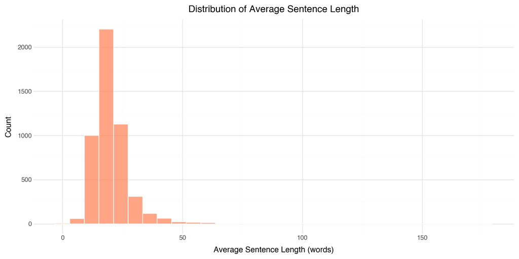

```python
(ggplot(mt_samples[mt_samples['avg_sentence_length'] > 0], aes(x='avg_sentence_length'))  # Hint: column name
 + geom_histogram(bins=30, fill='coral', color='white', alpha=0.7)
 + labs(x='Average Sentence Length (words)', y='Count', title='Distribution of Average Sentence Length')
 + theme_minimal()
 + theme(figure_size=(10, 5))
)
```

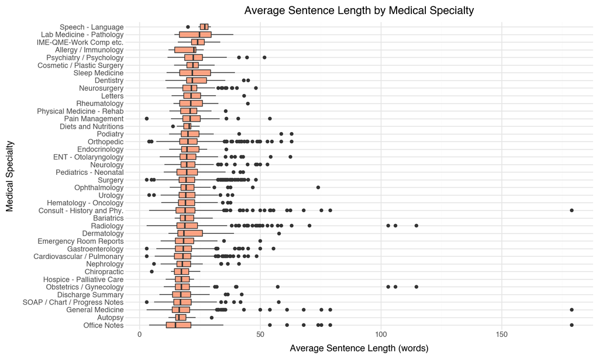

```python
(ggplot(mt_samples[mt_samples['avg_sentence_length'] > 0], aes(x='reorder(medical_specialty, avg_sentence_length)', y='avg_sentence_length'))  # Hint: aggregated by specialty
 + geom_boxplot(fill='coral', alpha=0.7)
 + coord_flip()
 + labs(x='Medical Specialty', y='Average Sentence Length (words)', title='Average Sentence Length by Medical Specialty')
 + theme_minimal()
 + theme(figure_size=(10, 6))
)
```

Summarize: Do you notice any patterns sentence length across different medical specialties?

Average sentence length is similar across most medical specialties. Most medians are around 15-25 words. A few medical specialties show more variabilitiy with some extremely long sentences as outliers, likely reflecting complex medical narratives or detailed clinical notes instead of simple clinical notes.

## Question 7: Topic Models

See if there are any themes in the data by using a topic model (LDA). - Remove combined NLTK + clinical stopwords - Use scikit-learn’s CountVectorizer to create a document-term matrix - Use LatentDirichletAllocation for topic modeling - Try different k (n_components) values (try 3 and 5) - Create a visualization of the topics

```python
# Prepare text data
texts = mt_samples['transcription'].dropna().tolist()

vectorizer = CountVectorizer(
    max_df=0.95,  # Ignore terms that appear in >95% of documents (filters common words)
    min_df=2,     # Ignore terms that appear in <2 documents (ignores very rare words)
    stop_words=list(all_stopwords),
    max_features=1000
)
dtm = vectorizer.fit_transform(texts)
```

```
Topic 1: pain, cervical, c5, spine, c6, mri, disc, l5, back, exam
Topic 2: placed, procedure, incision, anesthesia, removed, skin, room, diagnosis, fashion, closed
Topic 3: artery, procedure, catheter, coronary, vein, performed, pulmonary, stenosis, french, ventricular
Topic 4: foot, placed, medial, knee, lateral, tendon, joint, fracture, distal, procedure
Topic 5: history, mg, pain, past, blood, year, time, medications, negative, day
```

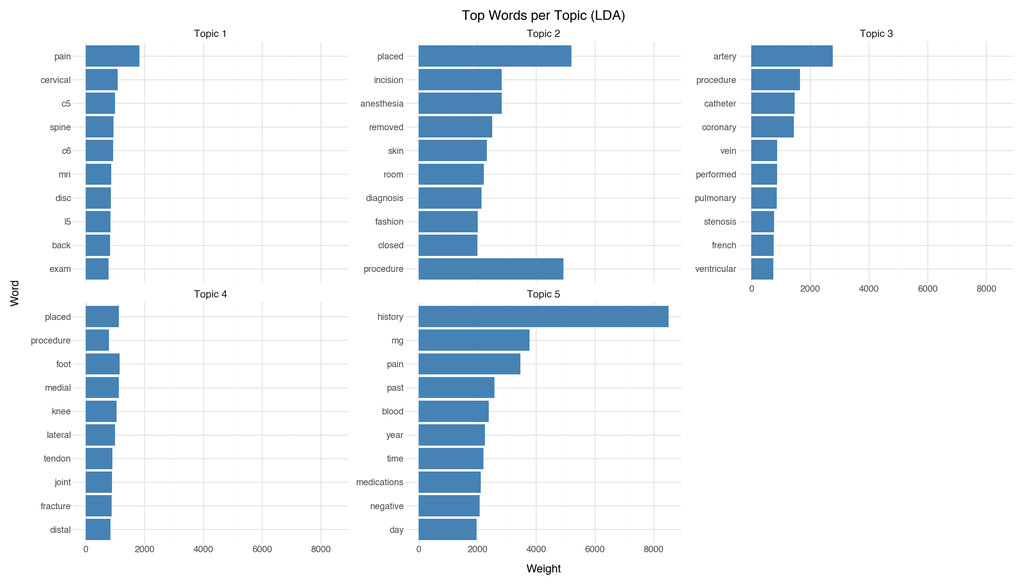

```python
n_topics = 5  # Hint: number of topics
lda = LatentDirichletAllocation(
    n_components=n_topics,  # Hint: use topic count
    random_state=42,
    max_iter=10
)
lda.fit(dtm)

feature_names = vectorizer.get_feature_names_out()

# Extract top words for each topic into a dataframe
def get_topic_df(model, feature_names, n_top_words=10):
    rows = []
    for topic_idx, topic in enumerate(model.components_):
        top_indices = topic.argsort()[:-n_top_words - 1:-1]
        for rank, idx in enumerate(top_indices):
            rows.append({
                'topic': f'Topic {topic_idx + 1}',
                'word': feature_names[idx],
                'weight': topic[idx],
                'rank': rank
            })
    return pd.DataFrame(rows)

topic_df = get_topic_df(lda, feature_names, 10)  # Hint: model, vocab list, top words

# Display top words per topic
for topic in topic_df['topic'].unique():
    words = topic_df[topic_df['topic'] == topic]['word'].tolist()
    print(f"{topic}: {', '.join(words)}")

# Visualize topics with faceted plot
(ggplot(topic_df, aes(x='reorder(word, weight)', y='weight'))  # Hint: topic dataframe
 + geom_bar(stat='identity', fill='steelblue')
 + coord_flip()
 + facet_wrap('~topic', scales='free_y', ncol=3)
 + labs(x='Word', y='Weight', title='Top Words per Topic (LDA)')
 + theme_minimal()
 + theme(figure_size=(14, 8), strip_text=element_text(size=10))
)
```

Summarize: is it clearer when there are 3 or 5 topics?

- Now do a cross tab of the 5 topics and the medical specialties.

```python
# Assign documents to topics and compare with actual specialties
doc_topic_dist = lda.transform(dtm)
dominant_topics = doc_topic_dist.argmax(axis=1)

# Add to dataframe
mt_samples_with_topics = mt_samples.dropna(subset=['transcription']).copy()
mt_samples_with_topics['dominant_topic'] = [f'Topic {t+1}' for t in dominant_topics]

# Cross-tabulation of topics vs specialties (top 5 specialties)
top_5_specialties = mt_samples_with_topics['medical_specialty'].value_counts().head(5).index.tolist()  # Hint: number of specialties
cross_tab = pd.crosstab(
    mt_samples_with_topics[mt_samples_with_topics['medical_specialty'].isin(top_5_specialties)]['medical_specialty'],
    mt_samples_with_topics[mt_samples_with_topics['medical_specialty'].isin(top_5_specialties)]['dominant_topic']
)
print("\nCross-tabulation of Topics vs Top 5 Specialties:")
print(cross_tab)
```

```
Cross-tabulation of Topics vs Top 5 Specialties:
dominant_topic              Topic 1  Topic 2  Topic 3  Topic 4  Topic 5
medical_specialty
Cardiovascular / Pulmonary        3       87      164        0      117
Consult - History and Phy.       39        0        1        6      470
Orthopedic                       82       54        2      171       46
Radiology                       136       20       78       20       19
Surgery                          25      717      152      165       29
```

Summarize: What themes emerge from the topic modeling? Do the topics align with the medical specialties?

The topic model discovers themes that resemble “Cardiovascular / Pulmonary”, “Consult - History and Phy.”, “Orthopedic”, “Surgery”, and “Radiology”. These topics are mostly related to the medical specialties in the cross-tab. However, personally, I feels Radiology is more mixed, suggesting some shared vocabs across different medical specialties.